# Assignment #2 DEG

Xinyi Zhang

# load all packages

```r
if(!requireNamespace("org.Hs.eg.db",quietly = TRUE))
  BiocManager::install("org.Hs.eg.db")
if(!requireNamespace("clusterProfiler",quietly = TRUE))
  BiocManager::install("clusterProfiler")
```

```r
if(!requireNamespace("biomaRt",quietly = TRUE))
  BiocManager::install("biomaRt")
if(!requireNamespace("tidyverse",quietly = TRUE))
  install.packages("tidyverse")
if(!requireNamespace("gplots",quietly = TRUE))
  install.packages("gplots")
if(!requireNamespace("RColorBrewer",quietly = TRUE))
  install.packages("RColorBrewer")
if(!requireNamespace("ggplot2",quietly = TRUE))
  install.packages("ggplot2")
if(!requireNamespace("edgeR",quietly = TRUE))
  BiocManager::install("edgeR")
if (!require(devtools)) install.packages("devtools")
  devtools::install_github("yanlinlin82/ggvenn")
library(org.Hs.eg.db)
library(clusterProfiler)
library(biomaRt)
library(tidyverse)
library(gplots)
library(RColorBrewer)
library(ggplot2)
library(edgeR)
library(ggvenn)
```

# load data from Assignment #1

The normlized input matrix is from assignment 1.

edgeR was used to find the DEGs from our dataset. Since the dataset only contains two treatment groups, i.e., control vs. treatment. The design matrix is created to perfrom the comparison between control and treatment.

```r
load("as1.RData")
normalized_counts<-normalized_counts[,c(4,5,6,1,2,3)]
group<-rep(c('control','treat'),each=3)

d <- DGEList(counts=normalized_counts,group=group)
design<-model.matrix(~group)

dge <- estimateDisp(d, design, robust = TRUE)

fit <- glmQLFit(dge, design, robust = TRUE)
lrt <- topTags(glmQLFTest(fit), n = nrow(d$counts))
res<-data.frame(lrt)
sigres<-res[res$FDR<0.05 & abs(res$logFC)>2,]
```

sigres contains the significant DEGs from our dataset. In total, 831 genes were identified as DEGs.

# volcano plot of DEGs.

Now, generatet the volcano plot for the DEGs. All DEGs are colored in the volcano plot.

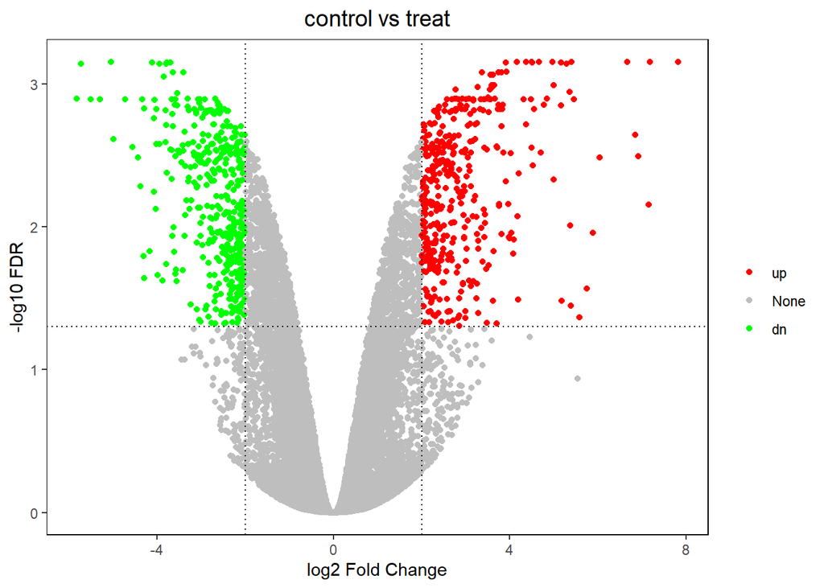

```r
res$color<-"None"
res$color[res$logFC >  2 & res$FDR<0.05]<-"up"
res$color[res$logFC < -2 & res$FDR<0.05]<-"dn"
ggplot(res,aes(x=logFC,y= -log10(FDR),color=color))+
  geom_point()+
  scale_color_manual(values = c('red', 'gray', 'green'), limits = c('up', 'None', 'dn'))+
  labs(x = 'log2 Fold Change', y = '-log10 FDR', title = 'control vs treat', color = '')+theme(plot.title = element_text(hjust = 0.5, size = 14), panel.grid = element_blank(),
    panel.background = element_rect(color = 'black', fill = 'transparent'),
    legend.key = element_rect(fill = 'transparent')) +
geom_vline(xintercept = c(-2, 2), lty = 3, color = 'black') +
geom_hline(yintercept = -log10(0.05), lty = 3, color = 'black')
```

From the volcano plot, we can see that most DEGs have a logFC around 2 to 4. Only a handful genes have large logFC values.

# heatmap of DEGs

Now, we generate the heatmap of DEGs. Normlized reads counts of DEGs were used to generate the heatmap.

```r
mat<-data.frame(normalized_counts)
head(mat)
```

```
##                 Mock1       Mock2        Mock3        Cov1        Cov2
## A1BG        8.4363973  39.1099303   10.4650121  12.5373164  11.6033119
## A1BG-AS1    4.7800660  11.4959492    6.4388024   7.5852729   7.6664739
## A1CF        0.9560132   0.4543073    0.3446561   0.5895290   1.0360100
## A2M      2115.3721039 408.1061970 1736.9726841 693.5218979 720.7728704
## A2M-AS1     2.7338623   3.8122306    4.4178644   1.0218502   0.6630464
## A2ML1       0.5199370   0.2765349    0.4543194   0.3144155   0.9945696
##                 Cov3
## A1BG       8.8022386
## A1BG-AS1   7.6712247
## A1CF       2.1145043
## A2M      870.4873078
## A2M-AS1    0.8851413
## A2ML1      0.2950471
```

```r
mat$gene<-rownames(mat)
sigres$gene<-rownames(sigres)

mat<-merge(mat,sigres,by="gene",all=FALSE)
rownames(mat)<-mat$gene
colnames(mat)
```

```
##  [1] "gene"   "Mock1"  "Mock2"  "Mock3"  "Cov1"   "Cov2"   "Cov3"   "logFC"
##  [9] "logCPM" "F"      "PValue" "FDR"
```

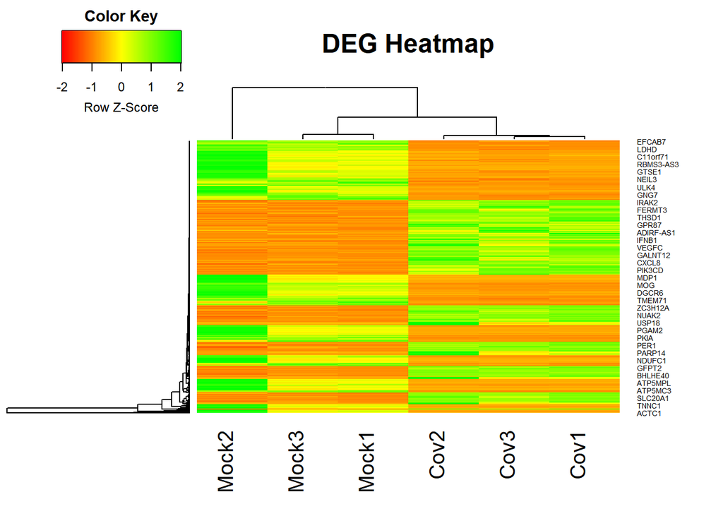

```r
mat[,c(1,8,9,10,11,12)]<-NULL



my_palette <- colorRampPalette(c("red", "yellow", "green"))(n = 100)
col_breaks = c(seq(-1,0,length=100),  # for red
  seq(0.01,0.8,length=100),           # for yellow
  seq(0.81,1,length=100))
heatmap.2(as.matrix(mat),  main = "DEG Heatmap", notecol="black",
  density.info="none",  trace="none", margins =c(6,6), scale="row",
  col=my_palette, dendrogram="both")
```

# GSEA

Now we do the GSEA analysis of the DEGs. Same procesure used for all DEGs, up-regulated DEGs, and down-regulated DEGs. Gene Ontology is used as genesets for GSEA analysis.

```r
sigall<-sigres
sigall$Gene<-rownames(sigall)
sigall<-sigall[,c(7,1)]
genename <- as.character(sigall[,1])
gene_map <- AnnotationDbi::select(org.Hs.eg.db, keys=genename, keytype="SYMBOL", columns=c("ENTREZID"))
colnames(gene_map)[1]<-"Gene"
sigall<-inner_join(gene_map,sigall,by = "Gene")
sigall$Gene<-NULL
sigall<-na.omit(sigall)
sigall$logFC<-sort(sigall$logFC,decreasing = T)
geneList = sigall[,2]
names(geneList) = as.character(sigall[,1])

Go_gseresult <- gseGO(geneList, 'org.Hs.eg.db', keyType = "ENTREZID", ont="all", nPerm = 1000, minGSSize = 10, maxGSSize = 1000, pvalueCutoff=1)
```

```
## preparing geneSet collections...
```

```
## GSEA analysis...
```

```
## leading edge analysis...
```

```
## done...
```

```r
GO_all<-data.frame(Go_gseresult)
GO_all<-GO_all[GO_all$p.adjust<0.05,]
head(GO_all)
```

```
##            ONTOLOGY         ID                              Description setSize
## GO:0044238       BP GO:0044238                primary metabolic process     408
## GO:0050896       BP GO:0050896                     response to stimulus     443
## GO:0050789       BP GO:0050789         regulation of biological process     510
## GO:0044260       BP GO:0044260 cellular macromolecule metabolic process     320
## GO:0032502       BP GO:0032502                    developmental process     324
## GO:0032501       BP GO:0032501         multicellular organismal process     388
##            enrichmentScore      NES      pvalue   p.adjust    qvalues rank
## GO:0044238       0.1888465 1.871640 0.001314060 0.01865339 0.01289596  323
## GO:0050896       0.2119421 2.102974 0.001326260 0.01865339 0.01289596  182
## GO:0050789       0.2012114 1.972935 0.001329787 0.01865339 0.01289596  430
## GO:0044260       0.2346773 2.279873 0.001333333 0.01865339 0.01289596  184
## GO:0032502       0.2644071 2.569545 0.001336898 0.01865339 0.01289596  187
## GO:0032501       0.2407554 2.375763 0.001338688 0.01865339 0.01289596  198
##                              leading_edge
## GO:0044238 tags=46%, list=39%, signal=55%
## GO:0050896 tags=28%, list=22%, signal=47%
## GO:0050789 tags=59%, list=52%, signal=74%
## GO:0044260 tags=31%, list=22%, signal=39%
## GO:0032502 tags=33%, list=23%, signal=42%
## GO:0032501 tags=32%, list=24%, signal=46%
##                                                                                                                                                                                                                                                                                                          …
## GO:0044238                                                                                                                                                                                                                                                                                               …
## GO:0050896                                                                                                                                                                                                                                                                                               …
## GO:0050789 3589/51129/2920/5743/3164/4929/81788/245711/80149/57699/5587…
## GO:0044260                                                                                                                                                                                                                                                                                               …
## GO:0032502                                                                                                                                                                                                                                                                                               …
## GO:0032501                                                                                                                                                                                                                                                                                               …
```

```r
nrow(GO_all)
```

```
## [1] 322
```

Repeat the process for up regulated genes and down regulated genes.

```r
sigall<-sigres[sigres$logFC > 0,]
sigall$Gene<-rownames(sigall)
sigall<-sigall[,c(7,1)]
genename <- as.character(sigall[,1])
gene_map <- AnnotationDbi::select(org.Hs.eg.db, keys=genename, keytype="SYMBOL", columns=c("ENTREZID"))
colnames(gene_map)[1]<-"Gene"
sigall<-inner_join(gene_map,sigall,by = "Gene")
sigall$Gene<-NULL
sigall<-na.omit(sigall)
sigall$logFC<-sort(sigall$logFC,decreasing = T)
geneList = sigall[,2]
names(geneList) = as.character(sigall[,1])

Go_gseresult <- gseGO(geneList, 'org.Hs.eg.db', keyType = "ENTREZID", ont="all", nPerm = 1000, minGSSize = 10, maxGSSize = 1000, pvalueCutoff=1)
```

```
## preparing geneSet collections...
```

```
## GSEA analysis...
```

```
## leading edge analysis...
```

```
## done...
```

```r
GO_up<-data.frame(Go_gseresult)
GO_up<-GO_up[GO_up$p.adjust<0.05,]
head(GO_up)
```

```
##            ONTOLOGY         ID                                  Description
## GO:0007275       BP GO:0007275           multicellular organism development
## GO:0009058       BP GO:0009058                         biosynthetic process
## GO:0044237       BP GO:0044237                   cellular metabolic process
## GO:0048731       BP GO:0048731                           system development
## GO:0032501       BP GO:0032501             multicellular organismal process
## GO:0034641       BP GO:0034641 cellular nitrogen compound metabolic process
##            setSize enrichmentScore      NES      pvalue   p.adjust     qvalues
## GO:0007275     170       0.2933392 1.813067 0.001002004 0.01338702 0.009512135
## GO:0009058     165       0.3452002 2.123987 0.001002004 0.01338702 0.009512135
## GO:0044237     247       0.3153126 1.950900 0.001002004 0.01338702 0.009512135
## GO:0048731     164       0.2925588 1.801989 0.001002004 0.01338702 0.009512135
## GO:0032501     227       0.2924592 1.812477 0.001003009 0.01338702 0.009512135
## GO:0034641     157       0.3125472 1.921207 0.001003009 0.01338702 0.009512135
##            rank                   leading_edge
## GO:0007275  210 tags=63%, list=51%, signal=52%
## GO:0009058  197 tags=63%, list=48%, signal=55%
## GO:0044237  197 tags=57%, list=48%, signal=74%
## GO:0048731  137 tags=44%, list=34%, signal=49%
## GO:0032501  111 tags=35%, list=27%, signal=57%
## GO:0034641  165 tags=53%, list=40%, signal=51%
##                                                                                                                                                                                                                                                                                                          …
## GO:0007275                                                                                                                                                                                    3589/51129/5743/3164/4929/80149/23764/2919/3394/8877/5806/35…
## GO:0009058                                                                                                                                                                                                3589/5743/3164/4929/80149/23764/90853/3394/57621/8877/5806/3…
## GO:0044237 3589/5743/3164/4929/81788/245711/80149/9518/23764/90853/330/…
## GO:0048731                                                                                                                                                                                                                                                                                               …
## GO:0032501                                                                                                                                                                                                                                                                                               …
## GO:0034641                                                                                                                                                                                                                                                                                               …
```

```r
nrow(GO_up)
```

```
## [1] 182
```

```r
sigall<-sigres[sigres$logFC < 0,]
sigall$Gene<-rownames(sigall)
sigall<-sigall[,c(7,1)]
genename <- as.character(sigall[,1])
gene_map <- AnnotationDbi::select(org.Hs.eg.db, keys=genename, keytype="SYMBOL", columns=c("ENTREZID"))
colnames(gene_map)[1]<-"Gene"
sigall<-inner_join(gene_map,sigall,by = "Gene")
sigall$Gene<-NULL
sigall<-na.omit(sigall)
sigall$logFC<-sort(sigall$logFC,decreasing = T)
geneList = sigall[,2]
names(geneList) = as.character(sigall[,1])

Go_gseresult <- gseGO(geneList, 'org.Hs.eg.db', keyType = "ENTREZID", ont="all", nPerm = 1000, minGSSize = 10, maxGSSize = 1000, pvalueCutoff=1)
```

```
## preparing geneSet collections...
```

```
## GSEA analysis...
```

```
## leading edge analysis...
```

```
## done...
```

```r
GO_dn<-data.frame(Go_gseresult)
GO_dn<-GO_dn[GO_dn$p.adjust<0.05,]
head(GO_dn)
```

```
##  [1] ONTOLOGY        ID              Description     setSize
##  [5] enrichmentScore NES             pvalue          p.adjust
##  [9] qvalues         rank            leading_edge    core_enrichment
## <0 rows> (or 0-length row.names)
```

```r
nrow(GO_dn)
```

```
## [1] 0
```

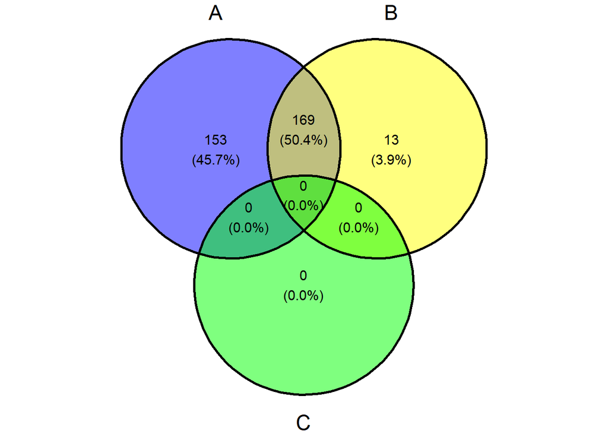

```r
set1<-GO_all$ID
set2<-GO_up$ID
set3<-GO_dn$ID

ggvenn(
  list(A=set1,B=set2,C=set3)
  )
```

From the GSEA results, we can see different input genes will give different results.